# Visualización de Grafos

Fernando Pérez (fperezgarciagm@gmail.com)

### Inicialización

Actualizar la variable workingDir de acuerdo al directorio específico de cada alumno.

```r
workingDir <- '/Users/fernando_perez/Documents/workspace_R/Master_TG/data'
```

# 1. Visualización con igraph

Cargamos como ejemplo para la visualización el grafo de Karate de Zackary. A lo largo de este módulo exploraremos las capacidades básicas para el ploteado de grafos con igraph http://igraph.org/r/doc/plot.common.html

```r
library(igraph)
library(networkD3)

inputFile <- "./karate.graphml"
g <- read.graph(file.path(workingDir, "karate.gml"), format = "gml")
```

Podemos hacer una visualización simple del grafo simplemente con plot:

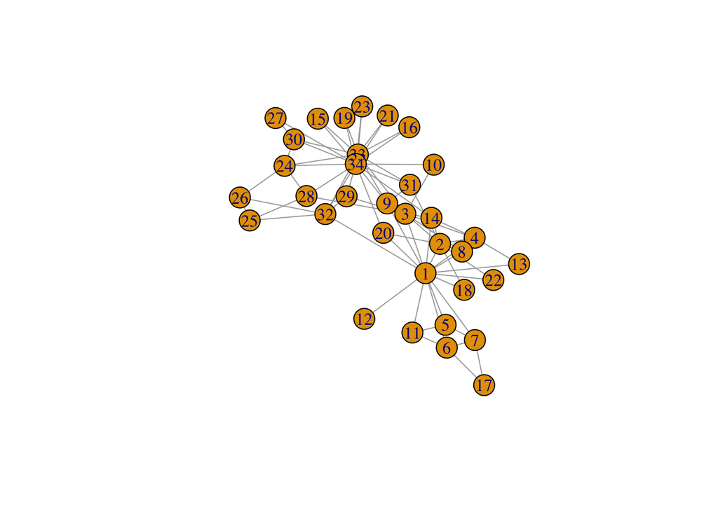

```r
plot(g)
```

A partir de esta visualización, vamos a intentar mejorarla

## a. Coloreado de los nodos por gradiente

La siguiente función añade a los nodos de un grafo la propiedad *color* como un gradiente de color dividido en N nivels (levels), en función de la centralidad del nodo.

```r
library(RColorBrewer)

colorGraph <- function (g, color = "degree", levels = 7, palette = "Blues"){

  switch(color,
         degree = {
           colIdx = cut(degree(g), levels, label=F)
         },
         pagerank = {
           colIdx = cut(page.rank(g)$vector, levels, label=F)
         },
         betweenness = {
           colIdx = cut(betweenness(g), levels, label=F)
         },
         closeness = {
           colIdx = cut(closeness(g), levels, label=F)
         }
  )

  V(g)$color = brewer.pal(levels, palette)[colIdx]

  g
}
```

Aplicamos la función sobre la propiedad *closeness* de nuestro grafo, en 7 niveles y vemos el resultados

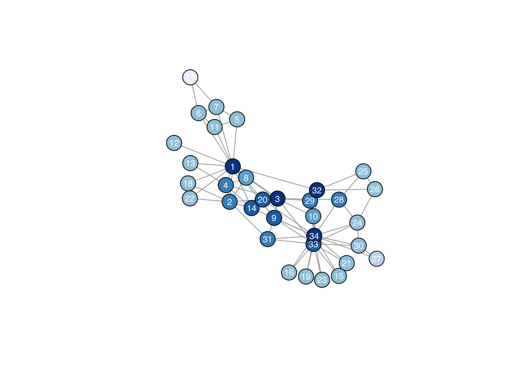

```r
g <- colorGraph(g,color = "closeness", levels = 7)

plot(g,
     vertex.label.family="sans",
     vertex.label.color="white",
     vertex.label.cex=0.7,
     vertex.color = V(g)$color)
```

## b. Variación del tamaño de los nodos

Variamos el tamaño de los nodos en función de su centralidad por grado

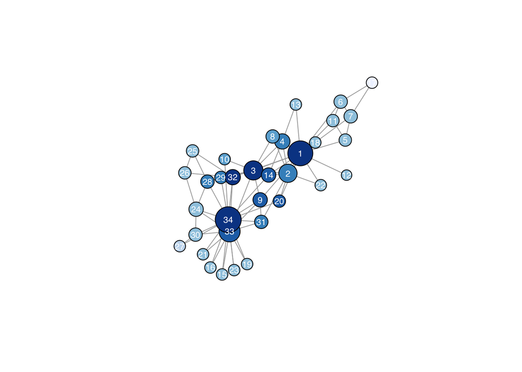

```r
V(g)$degree <- degree(g)

plot(g,vertex.label.family="sans",
     vertex.label.color="white",
     vertex.label.cex=0.7,
     vertex.color = V(g)$color,
     vertex.size = 10 + V(g)$degree)
```

## c. Identificación de comunidades

igraph incorpora multitud de funciones para la detección de comunidades como

- fastgreedy.community
- spinglass.community
- leading.eigenvector.community
- edge.betweenness.community
- walktrap.community

Todas ellas devuelven como resultado un objeto que contiene un vector *membership* donde se especifica la comunidad asignada a cada nodo.

Aplicamos una función de detección de comunidades y coloreamos según el resutado de la misma

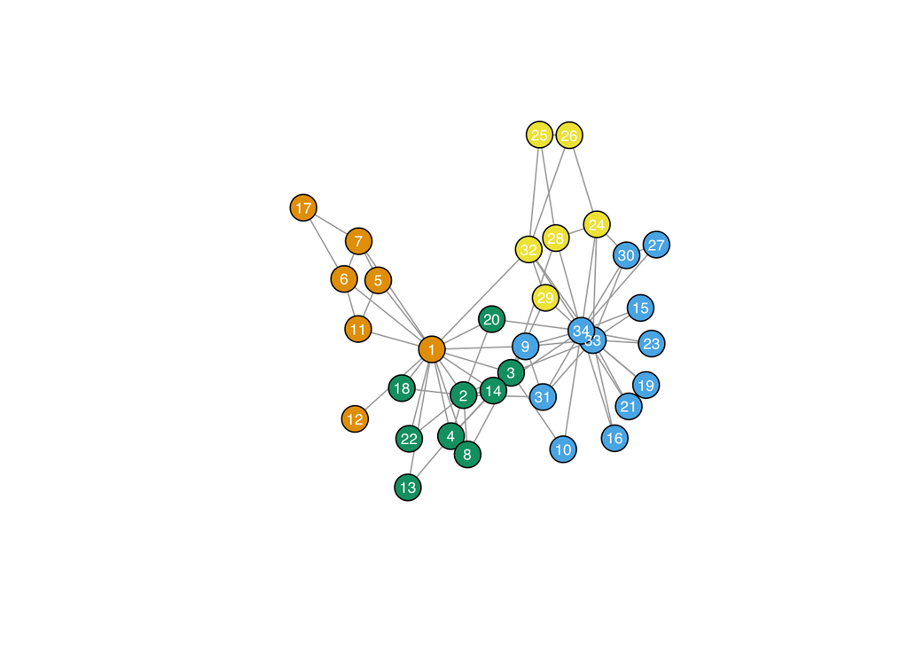

```r
communities=leading.eigenvector.community(g)
V(g)$membership <- communities$membership

plot(g,
     vertex.label.family="sans",
     vertex.label.color="white",
     vertex.label.cex=0.7,
     vertex.color = V(g)$membership)
```

## d. La disposición de los nodos. El “Layout”.

Mediante los algoritmo de Layout podemos variar la disposición de los nodos, igraph contiene diferentes algoritmos de layout, cada uno de los cuales admite parametrizaciones específicas. A continuación vamos a ver los principales aplicados sobre un grafo de tipo **Preferential Attachment** con 200 nodos

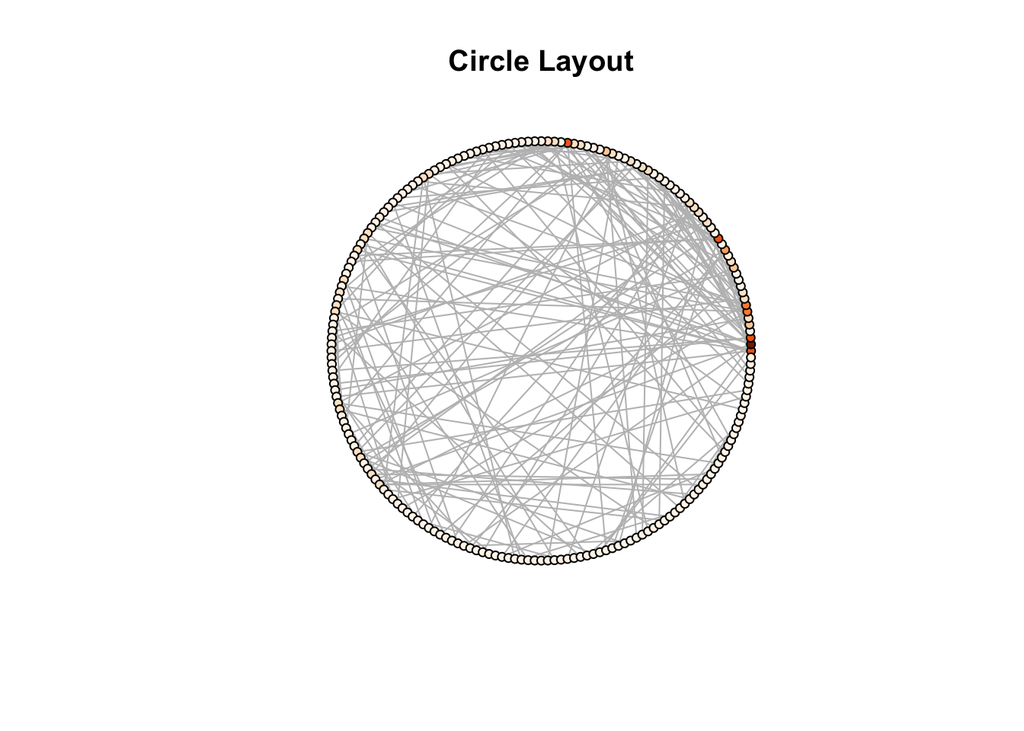

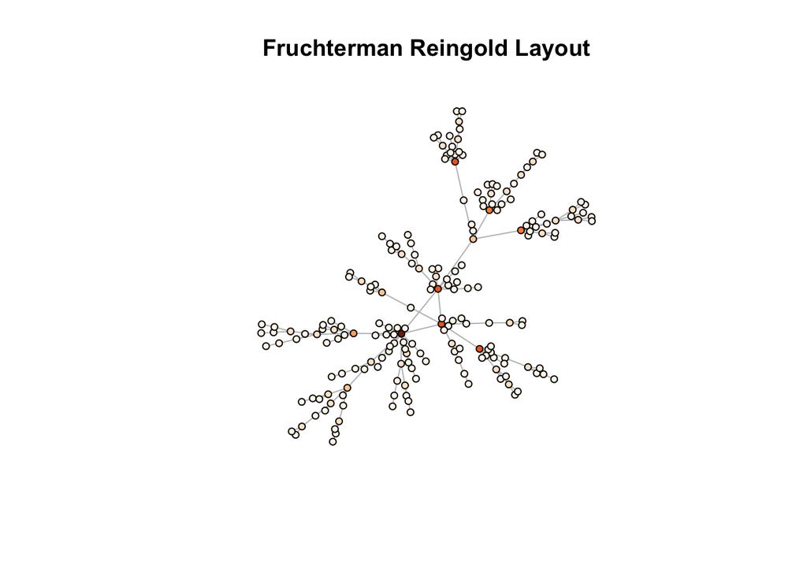

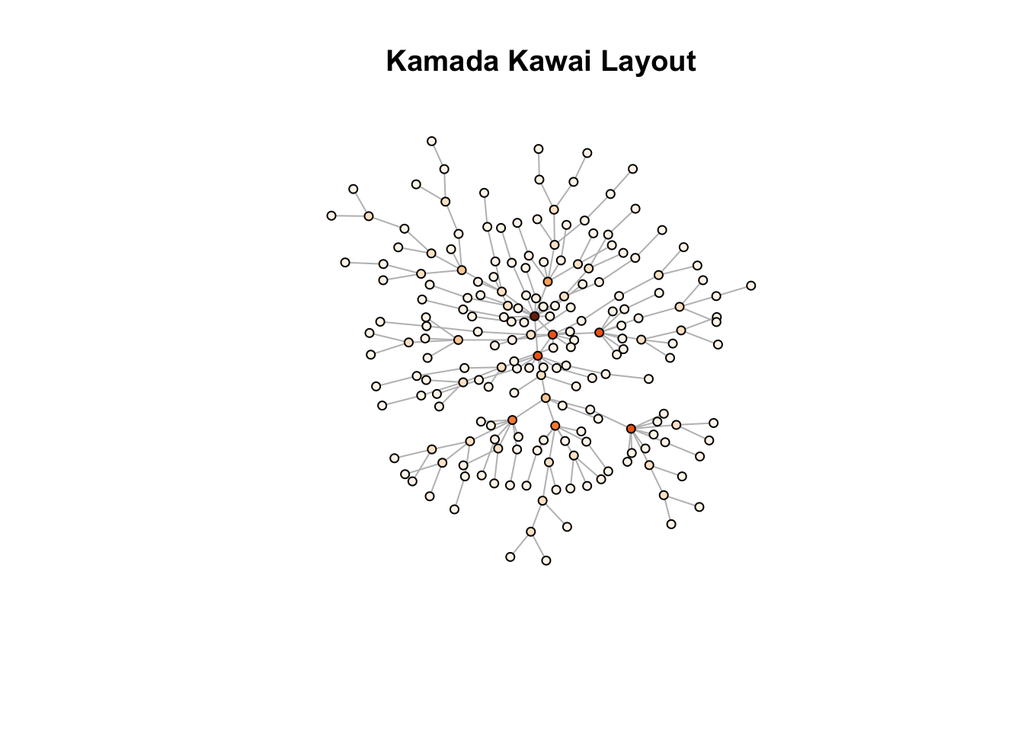

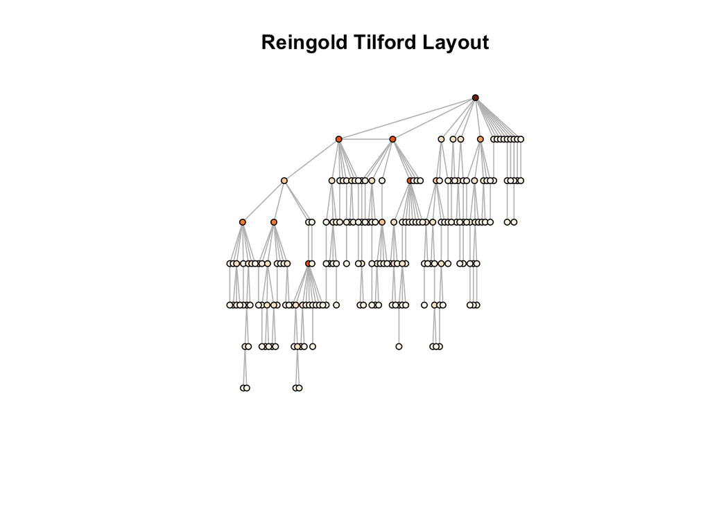

```r
gPA <- graph.full(n = 3, directed = FALSE, loops = FALSE)
gPA <- barabasi.game(n = 200, m = 1, start.graph = gPA,
                    out.pref = TRUE, directed = FALSE)

colorCriteria <- "degree"
gPA <- colorGraph(gPA, color = colorCriteria, levels = 9, palette = "Oranges")
```

### Función para resaltar las comunidades

La siguiente función permite resaltar las comunidades, asignando mas peso a los enlaces que conectan entre si nodos de la misma comunidad, para que ejerzan mayor atracción y se visualicen más próximos

```r
communities <- leading.eigenvector.community(g)
V(g)$membership <- communities$membership
E(g)$weight <- c(10, 1)[crossing(communities, g) + 1]
```

Aplicamos la función sobre el grafo de Karate y observamos el efecto con diferentes pesos

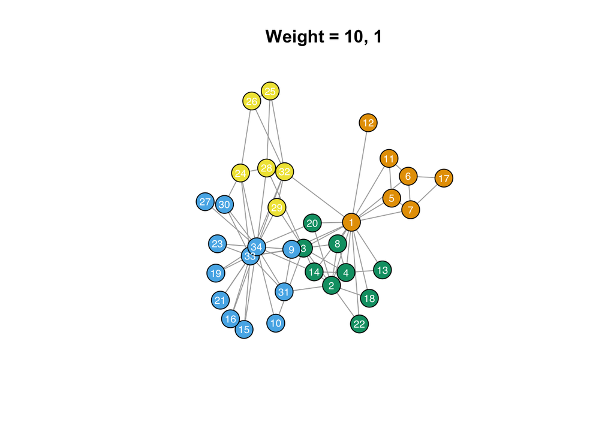

```r
l=layout.fruchterman.reingold(g, weights=E(g)$weight)
plot(g,
     layout = l,
     vertex.label.family="sans",
     vertex.label.color="white",
     vertex.label.cex=0.7,
     vertex.color = V(g)$membership,
     main="Weight = 10, 1")
```

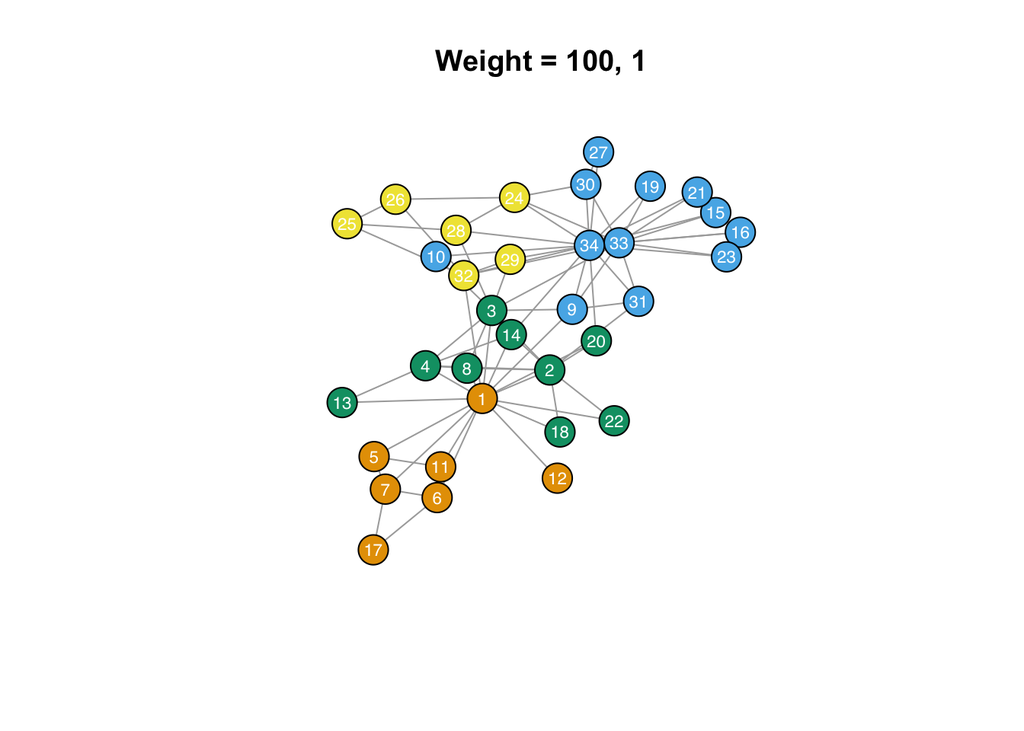

```r
E(g)$weight <- c(100, 1)[crossing(communities, g) + 1]

l=layout.fruchterman.reingold(g, weights=E(g)$weight)
plot(g,
     layout = l,
     vertex.label.family="sans",
     vertex.label.color="white",
     vertex.label.cex=0.7,
     vertex.color = V(g)$membership,
     main="Weight = 100, 1")
```

Finalmente aplicamos unos cuantos cambios para dar un aspecto mas atractivo a nuestro grafo:

```r
E(g)$weight <- c(2000, 100)[crossing(communities, g) + 1]

l=layout.fruchterman.reingold(g, weights = E(g)$weight, area = 10000)
```

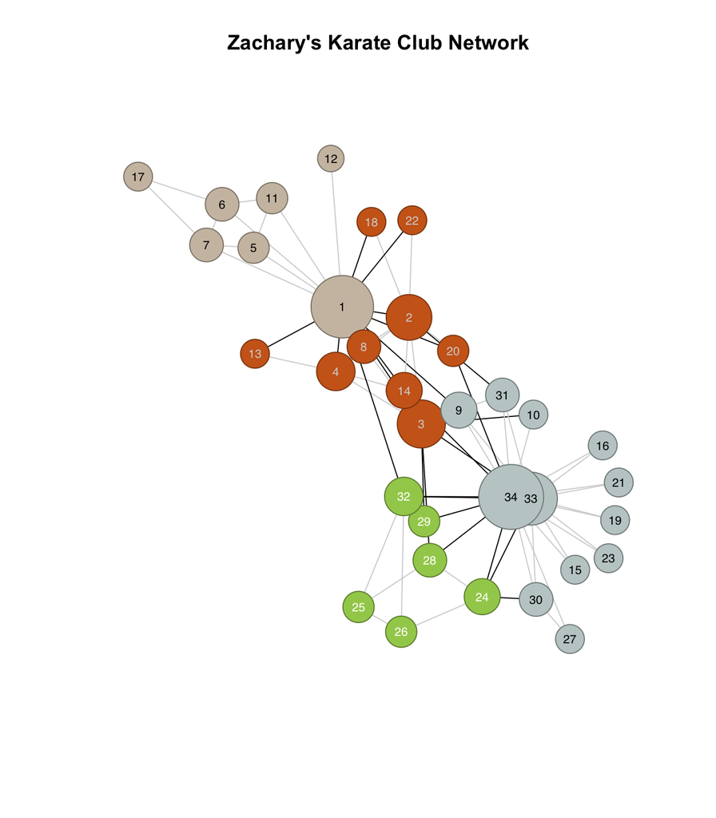

```r
#Node Colors
prettyColors <- c("antiquewhite3", "azure3", "chocolate3","darkolivegreen3")
communityColors <- prettyColors[V(g)$membership]

#Node Border Colors
prettyColorsBorder <- c("antiquewhite4", "azure4", "chocolate4","darkolivegreen4")
communityColorsBorder <- prettyColorsBorder[V(g)$membership]

#Label Color
prettyColorsFont <- c("black", "black", "lightgray", "white")
communityColorsFont <- prettyColorsFont[V(g)$membership]

#Identify Cross Community Edges
#Se suma 1 para convertir (False, True) en (1, 2)
edgeColors <- c("lightgray","black")[crossing(leading.eigenvector.community(g), g) + 1]

plot(g,
     layout = l,
     vertex.color = communityColors,
     vertex.frame.color = communityColorsBorder,
     vertex.size = 10 + V(g)$degree,
     edge.color = edgeColors,
     vertex.label.family = "sans",
     vertex.label.color = communityColorsFont,
     vertex.label.cex = 0.7,
     main = "Zachary's Karate Club Network")
```

# 2. Visualización interactiva con Network D3

Visualización sencilla con *simpleNetwork*

```r
library(networkD3)
source <- get.edgelist(g)[,1]
target <- get.edgelist(g)[,2]

networkData <- data.frame(source, target)
networkData["value"] <- get.data.frame(g, what="edges")[,3]

simpleNetwork(networkData)
```

[interactive chart not shown]

Visualización un poco mas elaborada con *forceNetwork*

```r
#Pasar el grafo a Data Frames y restar 1 a los identificadores de nodo, para que
#empiecen en el 0, por exigencias de la funcion forceNEtwork
dfVertex <- get.data.frame(g, what="vertices")
colnames(dfVertex) <- c("name", "color", "degree", "group")
dfVertex["name"] <- dfVertex$name - 1


dfEdges  <- get.data.frame(g, what="edges")
colnames(dfEdges) <- c("source", "target", "value")
dfEdges["source"] <- dfEdges$source - 1
dfEdges["target"] <- dfEdges$target - 1
dfEdges["edgeWidth"] <- ifelse(dfEdges$value > 100, 0.1,2)

#forceNetwork(Links = dfEdges,
#             Nodes = dfVertex,
#             Source = "source", Target = "target",
#             charge = -500,
#             Value = "edgeWidth", NodeID = "name",
#             Group = "group", opacity = 0.8,
#             fontsize = 32)

## Se puede guardar en HTML con la siguiente secuencia de comandos
#library(magrittr)
#simpleNetwork(networkData) %>%
#  saveNetwork(file = 'Net1.html')
```